# Tuto1 : Estimation du risque

```r
library(tidyverse)
theme_set(theme_classic(base_size=12))
```

## Exercice 1

On cherche à expliquer une variable binaire $Y$ par deux variables quantitatives $X_1$ et $X_2$ à l’aide du jeu de données suivant

```r
n <- 2000
set.seed(12345)
X1 <- runif(n)
set.seed(5678)
X2 <- runif(n)
set.seed(9012)
R1 <- X1<=0.25
R2 <- (X1>0.25 & X2>=0.75)
R3 <- (X1>0.25 & X2<0.75)
Y <- rep(0,n)
Y[R1] <- rbinom(sum(R1),1,0.25)
Y[R2] <- rbinom(sum(R2),1,0.25)
Y[R3] <- rbinom(sum(R3),1,0.75)
donnees <- data.frame(X1,X2,Y)
donnees$Y <- as.factor(donnees$Y)
indapp <- 1:1500
dapp <- donnees[indapp,]
dtest <- donnees[-indapp,]
```

On remarque que $X$ suit une loi uniforme sur le carré $[0,1]^2$. $Y|X=x$ suit une loi de Bernoulli de paramètre * 0.25 si $x_1\leq 0.25$ ou $x_1>0.25$ et $x_2\geq 0.75$. * 0.75 sinon.

On déduit que la règle de Bayes est donnée par

$$g^\star(x)=\left\{
\begin{array}{ll}
0 & \text{si }x_1\leq 0.25 \text{ ou }(x_1>0.25\text{ et }x_2\geq 0.75)\\
1 & \text{sinon.}
\end{array}\right.$$

L’erreur de Bayes vaut $L^\star=0.25$.

1. Représenter le nuage de points $X_2$ en fonction de $X_1$ en utilisant une couleur différente selon $Y$.

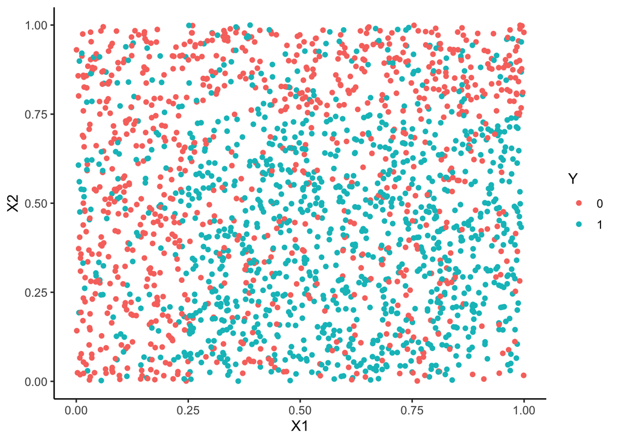

```r
ggplot(donnees)+aes(x=X1,y=X2,color=Y)+geom_point()
```

2. Charger le package *class* et ajuster la règle des 3 plus proches voisins sur les données d’apprentissage (fonction **knn**). Estimer la probabilité d’erreur de cette règle en utilisant l’échantillon test.

```r
library(class)
knn3 <- knn(dapp[,1:2],dtest[,1:2],cl=dapp$Y,k=3)
mean(knn3!=dtest$Y)
```

```
## [1] 0.308
```

3. On souhaite maintenant choisir $k$ dans le vecteur

```r
k_cand <- seq(1,100,by=2)
```

Calculer, pour chaque valeur de $k$, l’erreur de classification avec la même technique que dans la question précédente. Quelle valeur de $k$ choisissez vous ?

```r
erreur <- rep(0,length(k_cand))
compt <- 1
for (k in k_cand){
  knn_prev <- knn(dapp[,1:2],dtest[,1:2],cl=dapp$Y,k=k)
  erreur[compt] <- mean(knn_prev!=dtest$Y)
  compt <- compt+1
}
```

On choisit la valeur de $k$ pour laquelle l’erreur est la plus petite :

```r
k_cand[which.min(erreur)]
```

```
## [1] 27
```

4. On souhaite maintenant calculer l’erreur de la règle des 3 plus proches voisins avec de la validation croisée 10 blocs. Cette méthode nécessite de partitionner l’échantillon en 10 parties, on peut utiliser la fonction **createFolds** du package **caret**.

```r
library(caret)
K <- 10
kfolds <- createFolds(1:nrow(donnees),k=K)
```

On créé ensuite une fonction qui permet de calculer l’erreur pour une valeur de $k$ donnée :

```r
err_cv <- function(k){
  erreur_bloc <- rep(0,K)
  for (j in 1:K){
    train <- donnees[kfolds[[j]],]
    test <- donnees[-kfolds[[j]],]
    prev <- knn(train[,1:2],test[,1:2],cl=train$Y,k=k)
    erreur_bloc[j] <- mean(prev!=test$Y)
  }
  return(mean(erreur_bloc))
}
```

Calculer, pour chaque valeur de $k$, l’erreur de classification avec cette technique de validation croisée. Quelle valeur de $k$ choisissez-vous ?

```r
erreur_cv <- rep(0,length(k_cand))
compt <- 1
for (k in k_cand){
  erreur_cv[compt] <- err_cv(k)
  compt <- compt+1
}
k_cand[which.min(erreur_cv)]
```

```
## [1] 15
```

## Exercice 2

On souhaite ici refaire le même travail que dans l’exercice précédent avec le package **caret**.

1. Expliquer les sorties des commandes suivantes

```r
#donnees$Y <- as.factor(donnees$Y)
ctrl1 <- trainControl(method="LGOCV",number=1,index=list(1:1500))
KK <- data.frame(k=k_cand)
ee1 <- train(Y~.,data=donnees,method="knn",trControl=ctrl1,tuneGrid=KK)
ee1
```

```
## k-Nearest Neighbors
##
## 2000 samples
##    2 predictor
##    2 classes: '0', '1'
##
## No pre-processing
## Resampling: Repeated Train/Test Splits Estimated (1 reps, 75%)
## Summary of sample sizes: 1500
## Resampling results across tuning parameters:
##
##   k   Accuracy  Kappa
##    1  0.620     0.2298338
##    3  0.692     0.3797426
##    5  0.710     0.4138098
```

[output cut: 50 more lines]

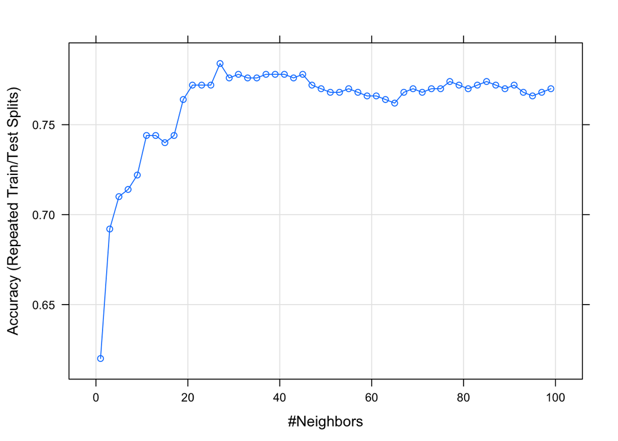

```r
plot(ee1)
```

La probabilité d’erreur est estimée par validation hold out (même résultat que dans la question 3 de l’exercice précédent).

2. Utiliser **caret** pour sélectionner $k$ par validation croisée. On pourra regarder l’aide de la fonction **trainControl**.

Il suffit d’utiliser **method=cv** dans **trainControl**.

```r
ctrl2 <- trainControl(method="cv")
ee2 <- train(Y~.,data=donnees,method="knn",trControl=ctrl2,tuneGrid=KK)
```

3. En utilisant l’option **index** dans **trainControl**, retrouver les résultats de l’exercice précédent pour la validation croisée 10 blocs.

```r
ctrl3 <- trainControl(method="cv",index=kfolds)
ee3 <- train(Y~.,data=donnees,method="knn",trControl=ctrl3,tuneGrid=KK)
```

```r
library(doMC)
detectCores()
```

```
## [1] 8
```

On peut ainsi comparer le temps de calcul avec 1 et 5 coeurs

```r
system.time(eee <- train(Y~.,data=donnees,method="knn",trControl=ctrl3,tuneGrid=KK))
```

```
##    user  system elapsed
##  14.857   0.078  14.993
```

```r
registerDoMC(cores = 5)
system.time(eee <- train(Y~.,data=donnees,method="knn",trControl=ctrl3,tuneGrid=KK))
```

```
##    user  system elapsed
##  21.584   1.344   5.282
```

```r
registerDoMC(cores = 1)
```

Sur les machines windows, on peut faire la même chose avec **doParallel** :

```r
library(doParallel)
cl <- makePSOCKcluster(1)
registerDoParallel(cl)
system.time(eee <- train(Y~.,data=donnees,method="knn",trControl=ctrl3,tuneGrid=KK))
```

```
##    user  system elapsed
##  14.999   0.085  15.148
```

```r
stopCluster(cl)
cl <- makePSOCKcluster(5)
registerDoParallel(cl)
system.time(eee <- train(Y~.,data=donnees,method="knn",trControl=ctrl3,tuneGrid=KK))
```

```
##    user  system elapsed
##   0.798   0.038   7.511
```

```r
stopCluster(cl)
```

## Exercice 3

On considère 3 scores qui ont été calculés sur 100 individus. Le tableau suivant fournit les valeurs de score ainsi que les groupes observés pour chaque individu.

```r
set.seed(1234)
S1 <- runif(100)
S2 <- runif(100)
S3 <- S1
S3[sample(100,25)] <- runif(25)
Y <- rep(0,n)
Y[S1>0.5] <- 1
df <- data.frame(S1,S2,S3,Y=as.factor(Y))
```

On peut visualiser les notes de score et les groupes avec

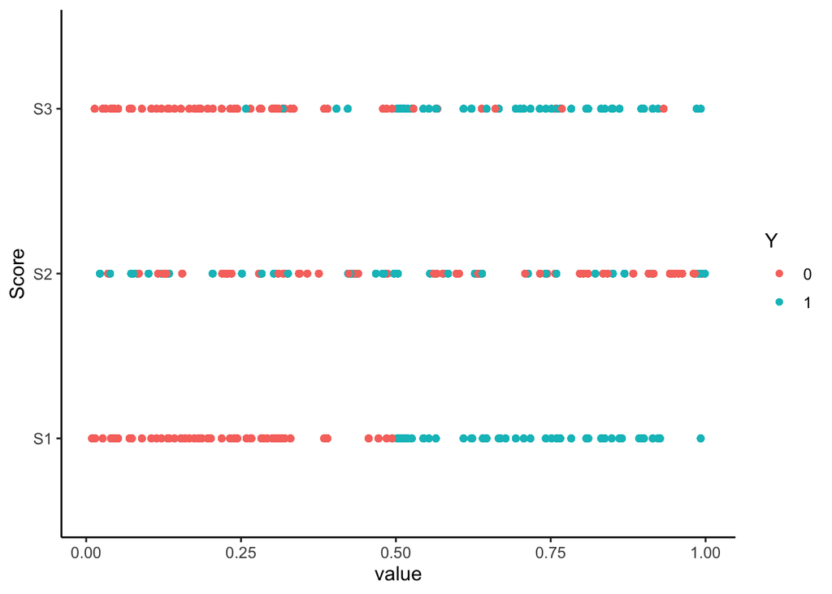

```r
df1 <- df %>% gather(key="Score",value="value",-Y)
ggplot(df1)+aes(x=value,y=Score,color=Y)+geom_point()
```

1. Tracer la courbe ROC de $S_1$ avec la fonction **roc** du package **pROC**.

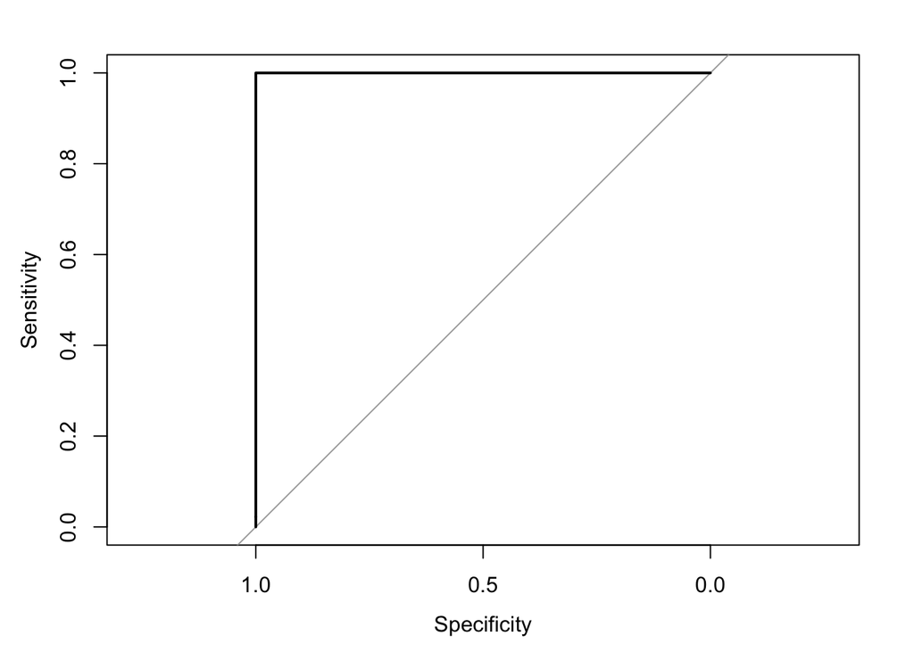

```r
library(pROC)
plot(roc(df$Y,df$S1))
```

2. Ajouter les courbes ROC de $S_2$ et $S_3$. On pourra utiliser l’option **add=TRUE**.

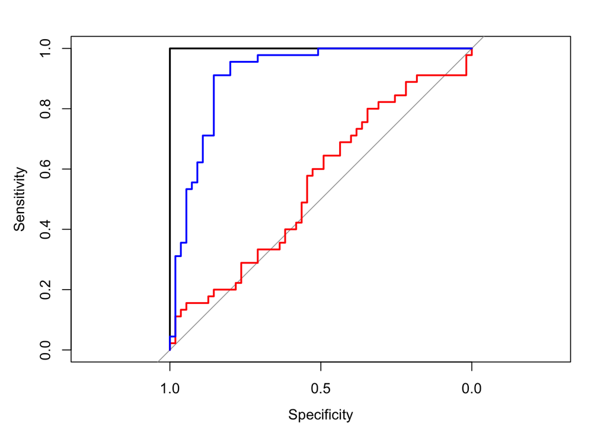

```r
plot(roc(df$Y,df$S1))
plot(roc(df$Y,df$S2),add=TRUE,col="red")
plot(roc(df$Y,df$S3),add=TRUE,col="blue")
```

3. Calculer les AUC des trois scores (fonction **auc**).

```r
auc(df$Y,df$S1)
```

```
## Area under the curve: 1
```

```r
auc(df$Y,df$S2)
```

```
## Area under the curve: 0.5519
```

```r
auc(df$Y,df$S3)
```

```
## Area under the curve: 0.9111
```

**Remarque** : on peut obtenir les courbes ROC et AUC en utilisant les outils du **tidyverse** (**ggplot** et **dplyr**).

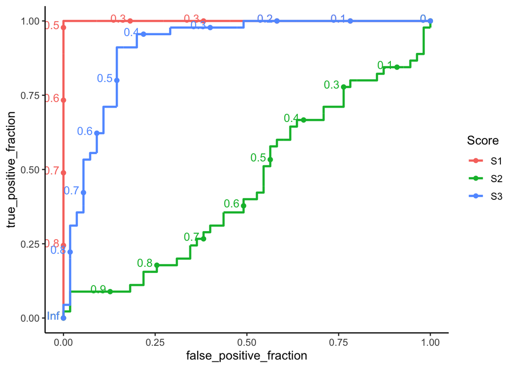

```r
df1 <- df %>% gather(key="Score",value="value",-Y)
df1$Y <- df1$Y %>% as.numeric()-1
library(plotROC)
ggplot(df1)+aes(d=Y,m=value,color=Score)+geom_roc()
```

```r
df1 %>% group_by(Score) %>% summarize(AUC=auc(Y,value)) %>%
  arrange(desc(AUC)) %>% mutate(AUC=round(AUC,3))
```

| Score | AUC |
| --- | --- |
| S1 | 1.000 |
| S3 | 0.911 |
| S2 | 0.552 |